# Apresentação resultados da análise

Leonardo de Mattos Galhardo e Victor Hugo Lopes Moreira

2023-04-11

Neste documento, apresentaremos o que foi desenvolvido e analisado, até o momento, dos dados dos fetos e de suas respectivas mães. Essa apresentação será divida entre a análise das duas tabelas, em partes.

Antes de começar os pacotes utilizados foram:

```r
library(ggplot2)
library(tidyverse)
library(readxl)
library(GGally)
library(ggpubr)
library(agricolae)
library(rstatix)
library(writexl)
```

# **Tabela “FETO_GERAL”**

Nessa seção, analisamos algumas das variávies dos fetos de camundongo

## Carregando a tabela

```r
dados_feto <- read_excel("D:/UFMG 2023.1/Lab 1/Rodada 1/Dados/RESULTADOS Corrigido 24-03.xlsx",
                         sheet = "FETO GERAL", col_types = c("numeric",
                                                             "text", "numeric", "numeric", "numeric",
                                                             "numeric", "numeric", "numeric",
                                                             "numeric", "numeric", "numeric",
                                                             "numeric"))
```

## Gráfico de correlação dos dados

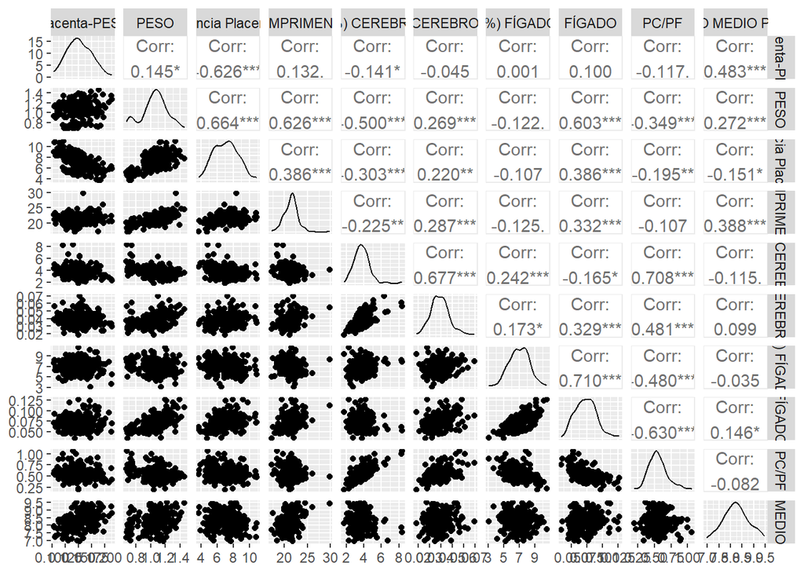

```r
cor <- dados_feto %>% select(`Placenta-PESO`,PESO,`Eficiência Placentária`,
                               COMPRIMENTO,`(%) CEREBRO`,CEREBRO,
                             `(%) FÍGADO`,FÍGADO,`PC/PF`,`DIAMETRO MEDIO PLACENTA`)

ggpairs(cor)
```

Pelo gráfico de correlações podemos visualizar um pouco melhor como as variáveis da tabela se relacionam entre si, além de como os dados das variáveis se distribuem. Algumas dessas correlações positivas são óbvias, como “`(%) FÍGADO`” e “`FÍGADO`” ou “`(%) CEREBRO`” e “`CEREBRO`”, que são variávies que são medidas diferentes para a mesma coisa.

## Boxplots

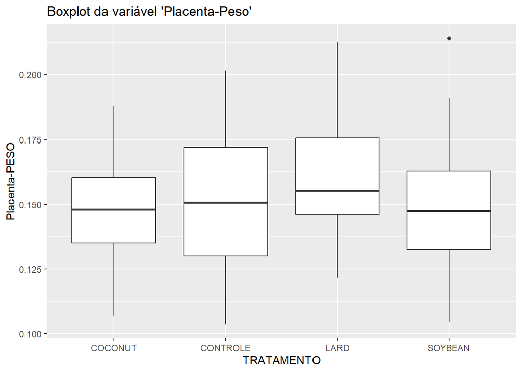

```r
# Boxplot Placenta-Peso por tipo de tratamento
ggplot(data = dados_feto, mapping = aes(x = `TRATAMENTO`, y = `Placenta-PESO`)) +
  geom_boxplot() +
  ggtitle("Boxplot da variável 'Placenta-Peso'")
```

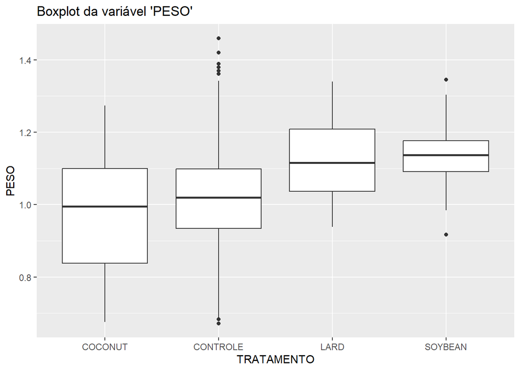

```r
# Boxplot PESO por tipo de tratamento
ggplot(data = dados_feto, mapping = aes(x = `TRATAMENTO`, y = PESO)) +
  geom_boxplot() +
  ggtitle("Boxplot da variável 'PESO'")
```

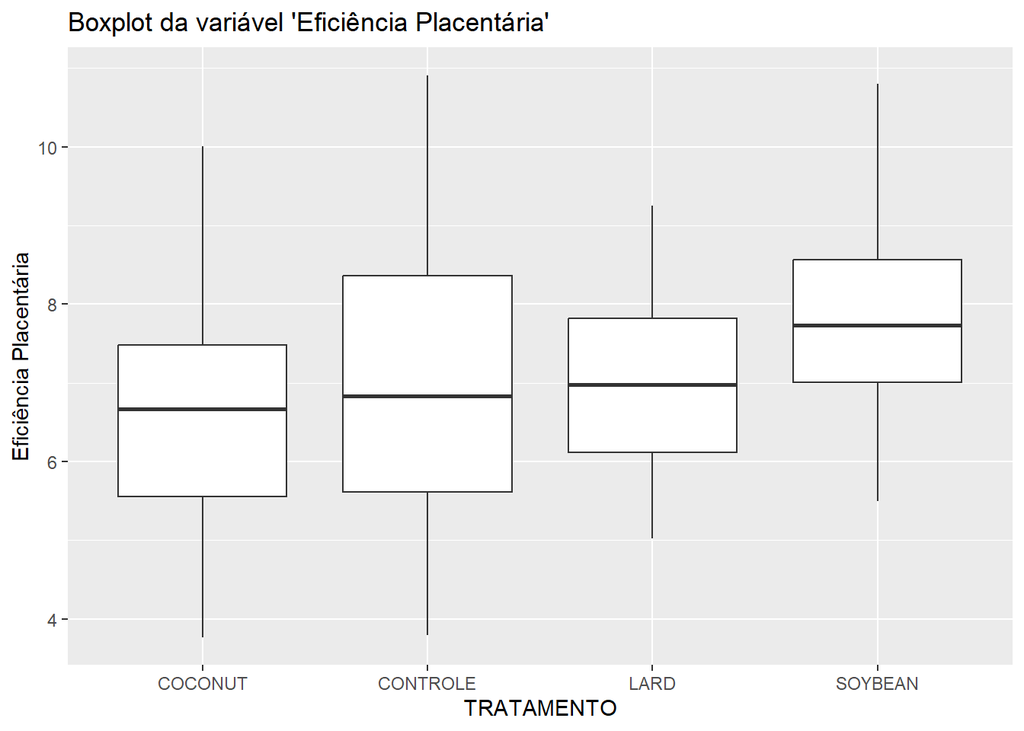

```r
# Boxplot Eficiência Placentária por tipo de tratamento
ggplot(data = dados_feto, mapping = aes(x = `TRATAMENTO`, y = `Eficiência Placentária`)) +
  geom_boxplot() +
  ggtitle("Boxplot da variável 'Eficiência Placentária'")
```

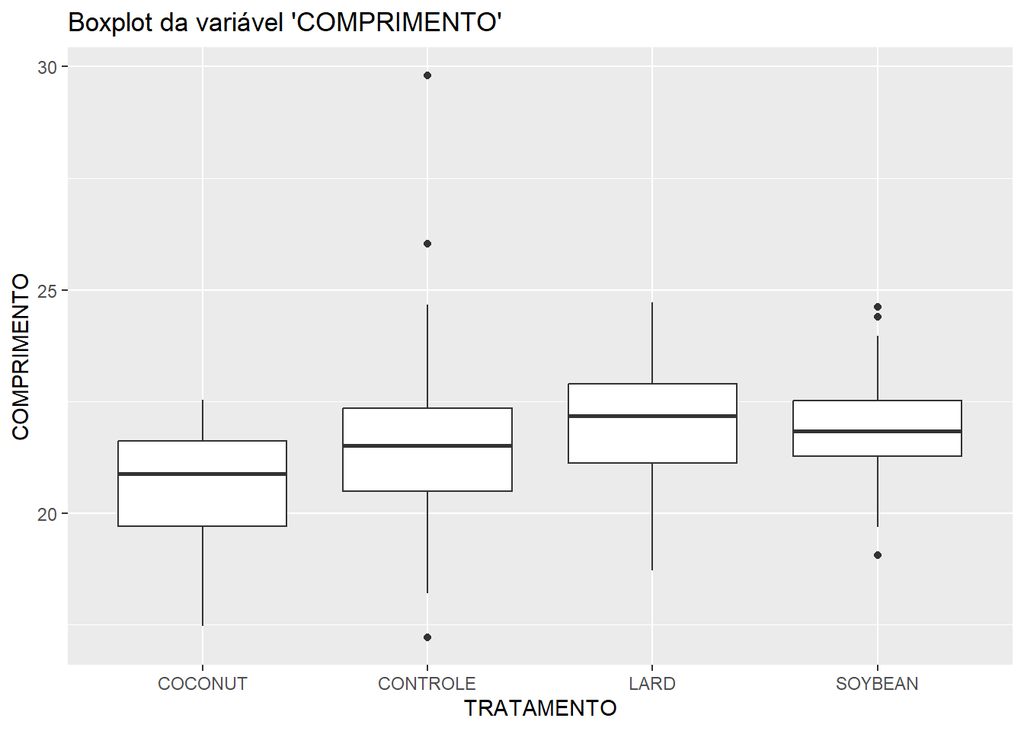

```r
# Boxplot COMPRIMENTO por tipo de tratamento
ggplot(data = dados_feto, mapping = aes(x = `TRATAMENTO`, y = COMPRIMENTO)) +
  geom_boxplot() +
  ggtitle("Boxplot da variável 'COMPRIMENTO'")
```

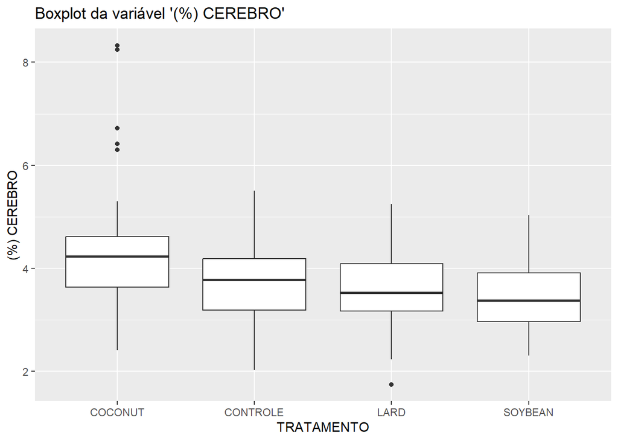

```r
# Boxplot '(%) CEREBRO' por tipo de tratamento
ggplot(data = dados_feto, mapping = aes(x = `TRATAMENTO`, y = `(%) CEREBRO`)) +
  geom_boxplot() +
  ggtitle("Boxplot da variável '(%) CEREBRO'")
```

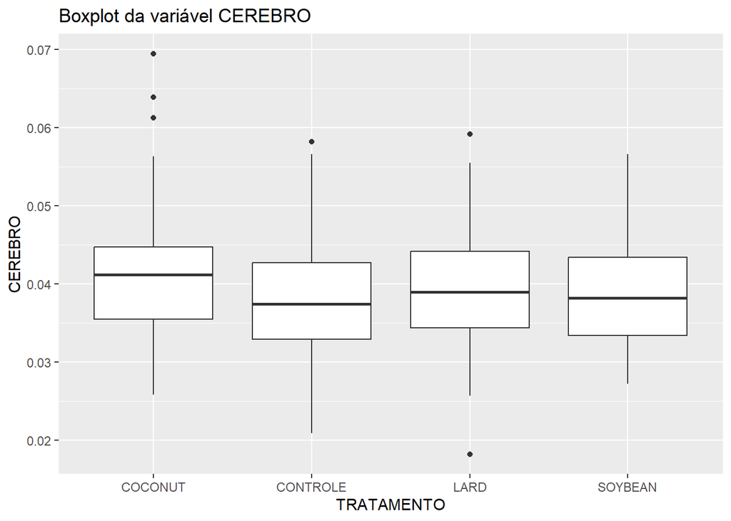

```r
# Boxplot CEREBRO por tipo de tratamento
ggplot(data = dados_feto, mapping = aes(x = `TRATAMENTO`, y = CEREBRO)) +
  geom_boxplot() +
  ggtitle("Boxplot da variável CEREBRO")
```

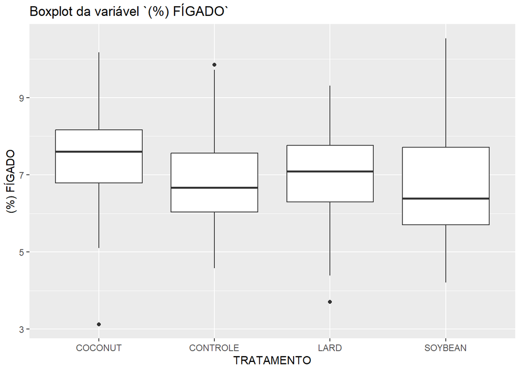

```r
# Boxplot `(%) FÍGADO` por tipo de tratamento
ggplot(data = dados_feto, mapping = aes(x = TRATAMENTO, y = `(%) FÍGADO`)) +
  geom_boxplot() +
  ggtitle("Boxplot da variável `(%) FÍGADO`")
```

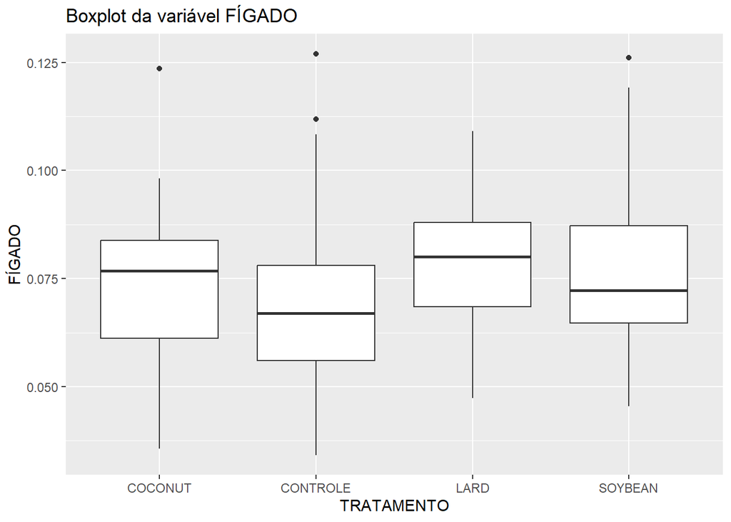

```r
# Boxplot FÍGADO` por tipo de tratamento
ggplot(data = dados_feto, mapping = aes(x = TRATAMENTO, y = FÍGADO)) +
  geom_boxplot() +
  ggtitle("Boxplot da variável FÍGADO")
```

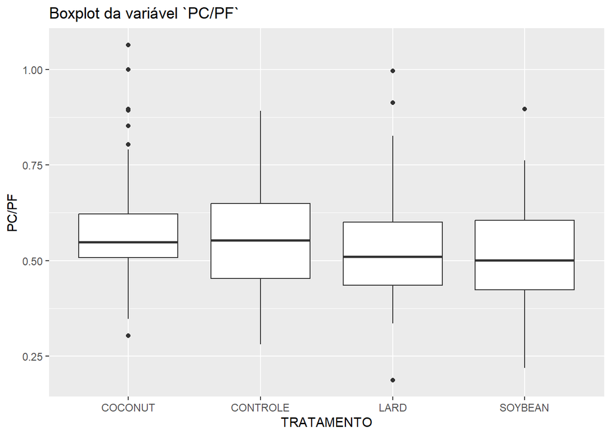

```r
# Boxplot `PC/PF` por tipo de tratamento
ggplot(data = dados_feto, mapping = aes(x = TRATAMENTO, y = `PC/PF`)) +
  geom_boxplot() +
  ggtitle("Boxplot da variável `PC/PF`")
```

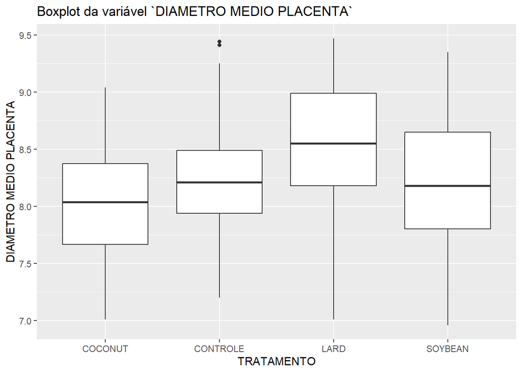

```r
# Boxplot `DIAMETRO MEDIO PLACENTA` por tipo de tratamento
ggplot(data = dados_feto, mapping = aes(x = TRATAMENTO, y = `DIAMETRO MEDIO PLACENTA`)) +
  geom_boxplot() +
  ggtitle("Boxplot da variável `DIAMETRO MEDIO PLACENTA`")
```

Pela análise dos Boxplots, podemos perceber que, alguns chamam mais atenção quanto às diferenças entre grupos de tratamento. Sendo assim, vale maior atenção nas comparações múltiplas entre os diferentes tratamentos das variáveis: “DIAMETRO MEDIO PLACENTA”, “FIGADO”, “(%) CEREBRO”, “COMPRIMENTO” e “PESO”.

## Gráfico de barras de erros

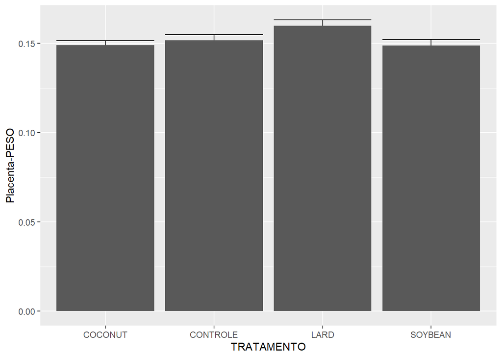

```r
# Gráfico de barras de erro para Placenta-PESO por tipo de tratamento

ggplot(data = dados_feto) +
  geom_errorbar(mapping = aes(x = `TRATAMENTO`, y = `Placenta-PESO`),
                stat = "summary",
                fun.data = "mean_se") +
  geom_bar(mapping = aes(x = `TRATAMENTO`, y = `Placenta-PESO`),
           stat = "summary",
           fun = "mean")
```

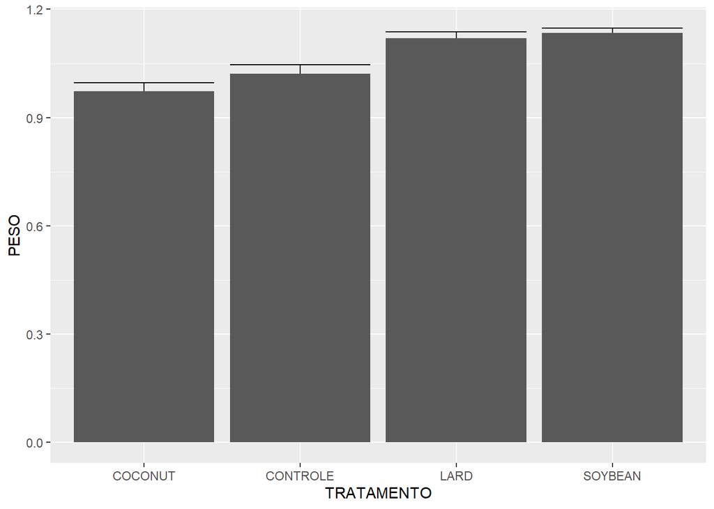

```r
# Gráfico de barras de erro para PESO por tipo de tratamento

ggplot(data = dados_feto) +
  geom_errorbar(mapping = aes(x = `TRATAMENTO`, y = PESO),
                stat = "summary",
                fun.data = "mean_se") +
  geom_bar(mapping = aes(x = `TRATAMENTO`, y = PESO),
           stat = "summary",
           fun = "mean")
```

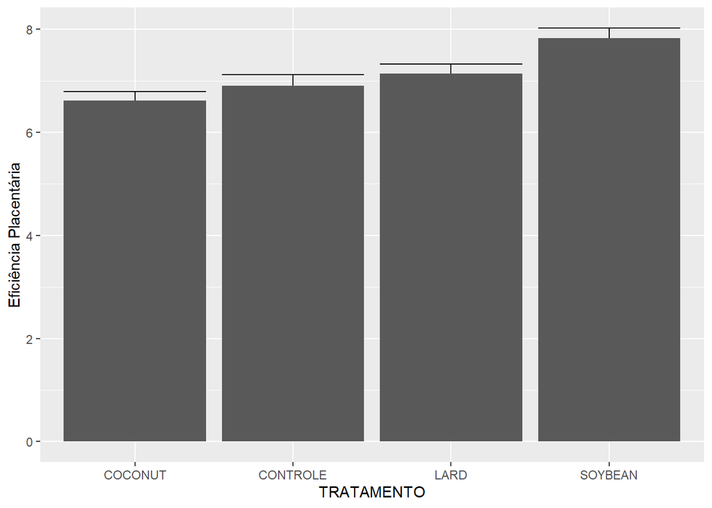

```r
# Gráfico de barras de erro para Eficiência Placentária por tipo de tratamento

ggplot(data = dados_feto) +
  geom_errorbar(mapping = aes(x = `TRATAMENTO`, y = `Eficiência Placentária`),
                stat = "summary",
                fun.data = "mean_se") +
  geom_bar(mapping = aes(x = `TRATAMENTO`, y = `Eficiência Placentária`),
           stat = "summary",
           fun = "mean")
```

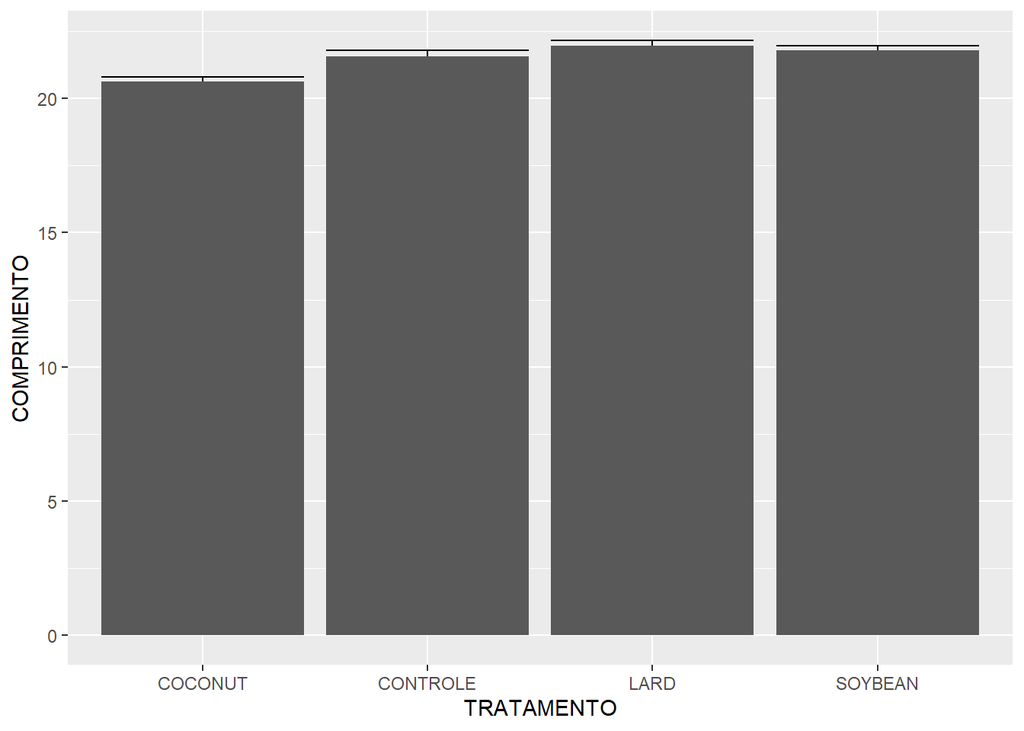

```r
# Gráfico de barras de erro para COMPRIMENTO por tipo de tratamento

ggplot(data = dados_feto) +
  geom_errorbar(mapping = aes(x = `TRATAMENTO`, y = COMPRIMENTO),
                stat = "summary",
                fun.data = "mean_se") +
  geom_bar(mapping = aes(x = `TRATAMENTO`, y = COMPRIMENTO),
           stat = "summary",
           fun = "mean")
```

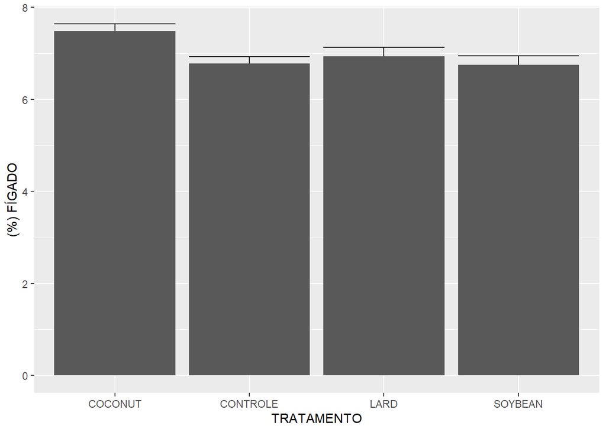

```r
# Gráfico de barras de erro para `(%) FÍGADO` por tipo de tratamento

ggplot(data = dados_feto) +
  geom_errorbar(mapping = aes(x = `TRATAMENTO`, y = `(%) FÍGADO`),
                stat = "summary",
                fun.data = "mean_se") +
  geom_bar(mapping = aes(x = `TRATAMENTO`, y = `(%) FÍGADO`),
           stat = "summary",
           fun = "mean")
```

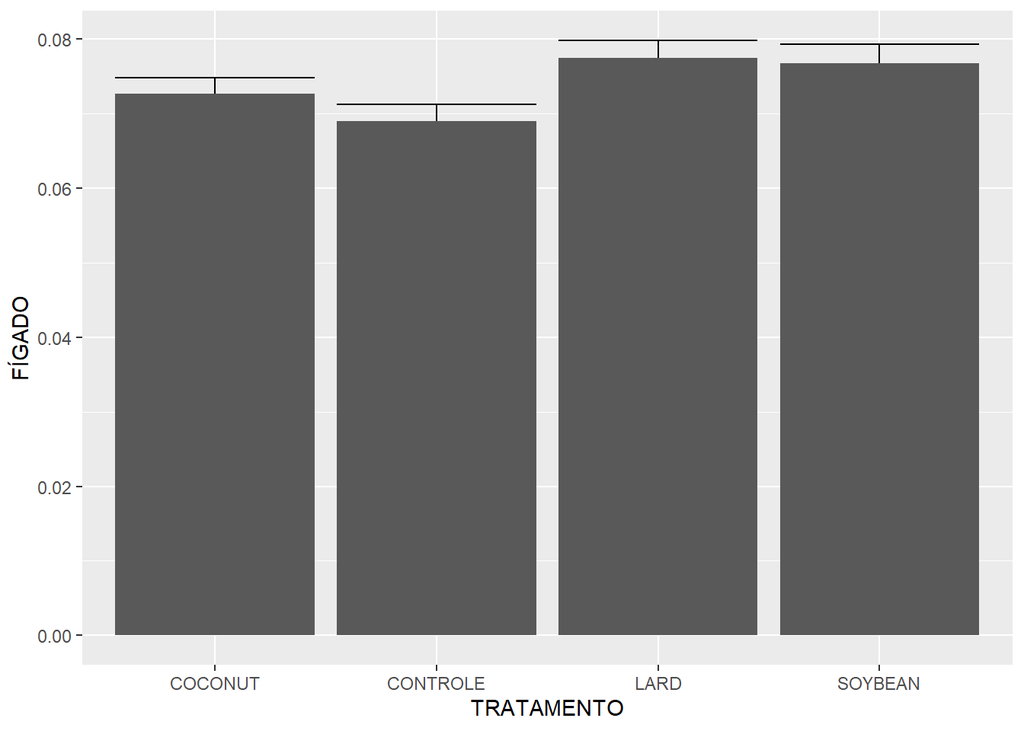

```r
# Gráfico de barras de erro para FÍGADO por tipo de tratamento

ggplot(data = dados_feto) +
  geom_errorbar(mapping = aes(x = `TRATAMENTO`, y = FÍGADO),
                stat = "summary",
                fun.data = "mean_se") +
  geom_bar(mapping = aes(x = `TRATAMENTO`, y = FÍGADO),
           stat = "summary",
           fun = "mean")
```

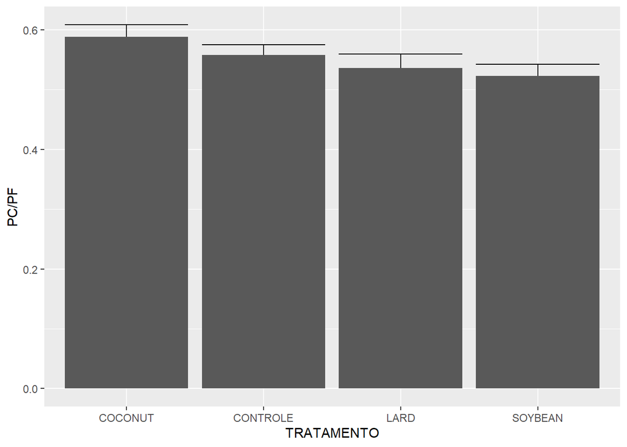

```r
# Gráfico de barras de erro para `PC/PF` por tipo de tratamento

ggplot(data = dados_feto) +
  geom_errorbar(mapping = aes(x = `TRATAMENTO`, y = `PC/PF`),
                stat = "summary",
                fun.data = "mean_se") +
  geom_bar(mapping = aes(x = `TRATAMENTO`, y = `PC/PF`),
           stat = "summary",
           fun = "mean")
```

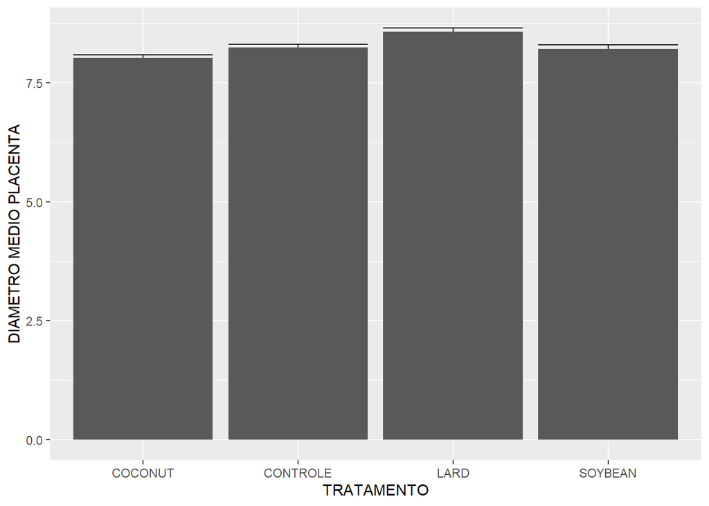

```r
# Gráfico de barras de erro para `DIAMETRO MEDIO PLACENTA` por tipo de tratamento

ggplot(data = dados_feto) +
  geom_errorbar(mapping = aes(x = `TRATAMENTO`, y = `DIAMETRO MEDIO PLACENTA`),
                stat = "summary",
                fun.data = "mean_se") +
  geom_bar(mapping = aes(x = `TRATAMENTO`, y = `DIAMETRO MEDIO PLACENTA`),
           stat = "summary",
           fun = "mean")
```

O gráfico de barras de erro nos mostra as médias e o erro padrão dentro de cada tratamento.

## Tabela Descritiva por Tratamento

```r
dados_coco <- dados_feto %>% filter(TRATAMENTO == "COCONUT")

(descritiva_coco <- dados_coco %>% get_summary_stats(`Placenta-PESO`,PESO,
                                               `Eficiência Placentária`,
                                               COMPRIMENTO,`(%) FÍGADO`,FÍGADO,
                                               `PC/PF`,`DIAMETRO MEDIO PLACENTA`))
```

```
## # A tibble: 8 x 13
##   variable         n    min    max median     q1     q3   iqr   mad   mean    sd
##   <fct>        <dbl>  <dbl>  <dbl>  <dbl>  <dbl>  <dbl> <dbl> <dbl>  <dbl> <dbl>
## 1 Placenta-PE~    55  0.107  0.188  0.148  0.135  0.16  0.025 0.019  0.149 0.019
## 2 PESO            56  0.676  1.27   0.995  0.838  1.1   0.262 0.179  0.973 0.167
## 3 Eficiência ~    55  3.77  10.0    6.66   5.55   7.48  1.93  1.47   6.62  1.30
## 4 COMPRIMENTO     56 17.5   22.5   20.9   19.7   21.6   1.9   1.26  20.6   1.24
## 5 (%) FÍGADO      56  3.13  10.2    7.60   6.79   8.17  1.38  1.01   7.48  1.19
## 6 FÍGADO          56  0.036  0.124  0.077  0.061  0.084 0.023 0.014  0.073 0.017
## 7 PC/PF           55  0.304  1.06   0.549  0.508  0.622 0.114 0.085  0.588 0.151
## 8 DIAMETRO ME~    56  7.01   9.04   8.04   7.66   8.37  0.707 0.556  8.02  0.488
## # ... with 2 more variables: se <dbl>, ci <dbl>
```

```r
dados_cont <- dados_feto %>% filter(TRATAMENTO == "CONTROLE")

(descritiva_cont <- dados_cont %>% get_summary_stats(`Placenta-PESO`,PESO,
                                                    `Eficiência Placentária`,
                                                    COMPRIMENTO,`(%) FÍGADO`,FÍGADO,
                                                    `PC/PF`,`DIAMETRO MEDIO PLACENTA`))
```

```
## # A tibble: 8 x 13
##   variable         n    min    max median     q1     q3   iqr   mad   mean    sd
##   <fct>        <dbl>  <dbl>  <dbl>  <dbl>  <dbl>  <dbl> <dbl> <dbl>  <dbl> <dbl>
## 1 Placenta-PE~    62  0.104  0.202  0.151  0.13   0.172 0.042 0.033  0.152 0.026
## 2 PESO            66  0.672  1.46   1.02   0.934  1.10  0.165 0.125  1.02  0.201
## 3 Eficiência ~    62  3.79  10.9    6.84   5.61   8.37  2.76  2.17   6.9   1.73
## 4 COMPRIMENTO     65 17.2   29.8   21.5   20.5   22.3   1.86  1.32  21.6   1.79
## 5 (%) FÍGADO      66  4.58   9.86   6.67   6.04   7.56  1.52  1.16   6.78  1.20
## 6 FÍGADO          66  0.034  0.127  0.067  0.056  0.078 0.022 0.017  0.069 0.018
## 7 PC/PF           65  0.281  0.892  0.554  0.453  0.649 0.195 0.149  0.558 0.137
## 8 DIAMETRO ME~    66  7.2    9.44   8.21   7.94   8.49  0.55  0.415  8.24  0.494
## # ... with 2 more variables: se <dbl>, ci <dbl>
```

```r
dados_lard <- dados_feto %>% filter(TRATAMENTO == "LARD")

(descritiva_lard <- dados_lard %>% get_summary_stats(`Placenta-PESO`,PESO,
                                                    `Eficiência Placentária`,
                                                    COMPRIMENTO,`(%) FÍGADO`,FÍGADO,
                                                    `PC/PF`,`DIAMETRO MEDIO PLACENTA`))
```

```
## # A tibble: 8 x 13
##   variable         n    min    max median     q1     q3   iqr   mad   mean    sd
##   <fct>        <dbl>  <dbl>  <dbl>  <dbl>  <dbl>  <dbl> <dbl> <dbl>  <dbl> <dbl>
## 1 Placenta-PE~    45  0.122  0.212  0.155  0.146  0.176 0.029 0.025  0.16  0.022
## 2 PESO            45  0.939  1.34   1.12   1.04   1.21  0.173 0.138  1.12  0.115
## 3 Eficiência ~    45  5.02   9.25   6.98   6.12   7.82  1.7   1.27   7.14  1.21
## 4 COMPRIMENTO     45 18.7   24.7   22.2   21.1   22.9   1.77  1.05  22.0   1.36
## 5 (%) FÍGADO      43  3.71   9.31   7.09   6.29   7.76  1.47  1.14   6.94  1.25
## 6 FÍGADO          43  0.047  0.109  0.08   0.068  0.088 0.02  0.013  0.078 0.015
## 7 PC/PF           42  0.188  0.996  0.51   0.436  0.6   0.165 0.122  0.536 0.155
## 8 DIAMETRO ME~    45  7.01   9.47   8.55   8.18   8.99  0.81  0.563  8.57  0.509
## # ... with 2 more variables: se <dbl>, ci <dbl>
```

```r
dados_soy <- dados_feto %>% filter(TRATAMENTO == "SOYBEAN")

(descritiva_soy <- dados_soy %>% get_summary_stats(`Placenta-PESO`,PESO,
                                                    `Eficiência Placentária`,
                                                    COMPRIMENTO,`(%) FÍGADO`,FÍGADO,
                                                    `PC/PF`,`DIAMETRO MEDIO PLACENTA`))
```

```
## # A tibble: 8 x 13
##   variable         n    min    max median     q1     q3   iqr   mad   mean    sd
##   <fct>        <dbl>  <dbl>  <dbl>  <dbl>  <dbl>  <dbl> <dbl> <dbl>  <dbl> <dbl>
## 1 Placenta-PE~    45  0.105  0.214  0.148  0.132  0.163 0.03  0.022  0.149 0.024
## 2 PESO            46  0.917  1.34   1.14   1.09   1.18  0.085 0.068  1.14  0.085
## 3 Eficiência ~    45  5.50  10.8    7.73   7.01   8.56  1.55  1.23   7.83  1.27
## 4 COMPRIMENTO     46 19.0   24.6   21.8   21.3   22.5   1.24  0.979 21.8   1.2
## 5 (%) FÍGADO      46  4.20  10.5    6.39   5.70   7.71  2.01  1.29   6.75  1.33
## 6 FÍGADO          46  0.045  0.126  0.072  0.065  0.087 0.023 0.014  0.077 0.017
## 7 PC/PF           46  0.22   0.896  0.501  0.423  0.605 0.182 0.125  0.522 0.135
## 8 DIAMETRO ME~    46  6.96   9.35   8.18   7.80   8.65  0.847 0.6    8.2   0.608
## # ... with 2 more variables: se <dbl>, ci <dbl>
```

## Análise de Normalidade

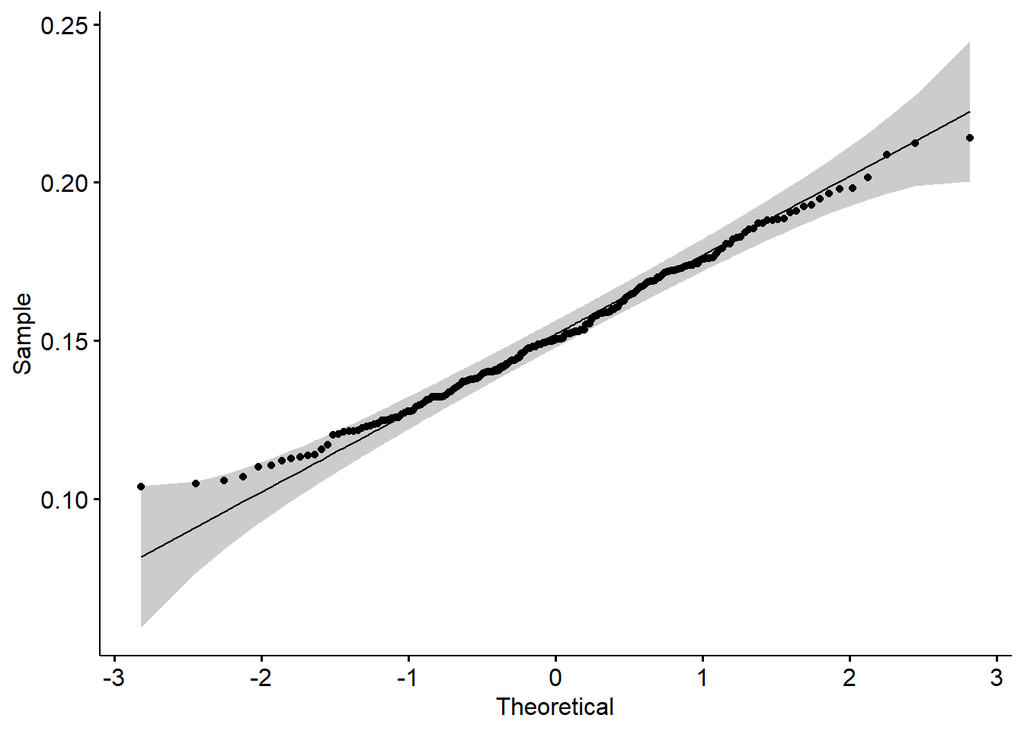

```r
# QQ Normal Plot do ggpubr
ggqqplot(dados_feto$`Placenta-PESO`)
```

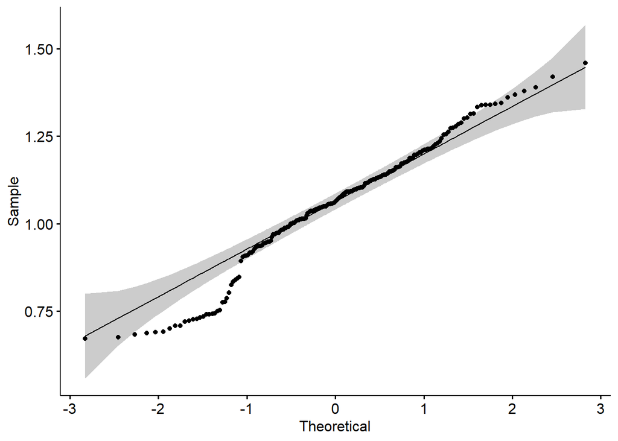

```r
ggqqplot(dados_feto$PESO)
```

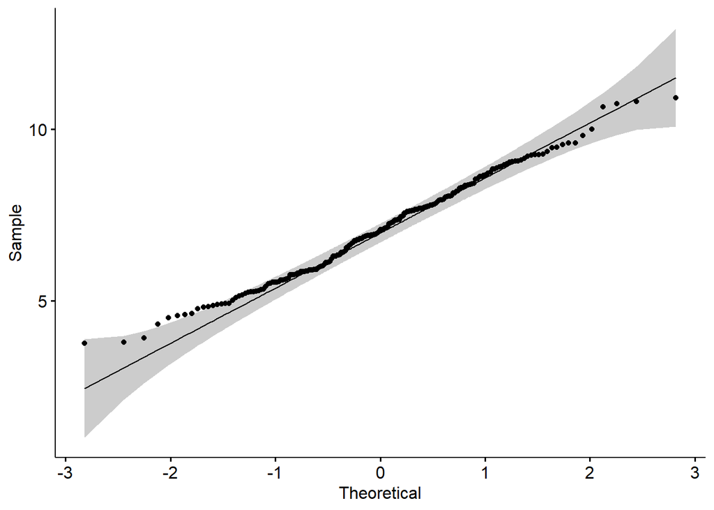

```r
ggqqplot(dados_feto$`Eficiência Placentária`)
```

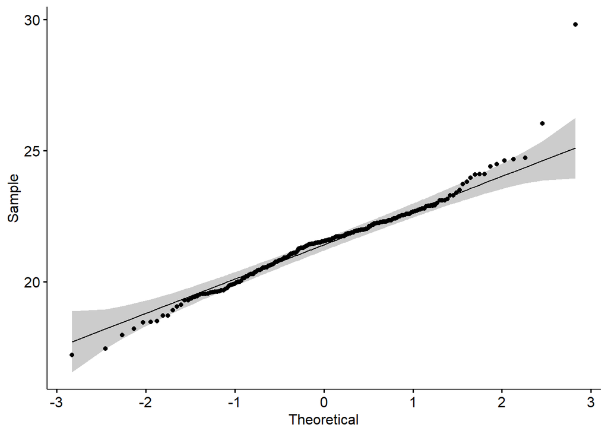

```r
ggqqplot(dados_feto$COMPRIMENTO)
```

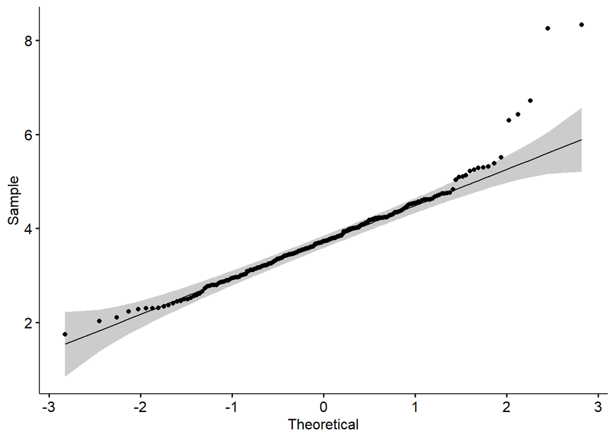

```r
ggqqplot(dados_feto$`(%) CEREBRO`)
```

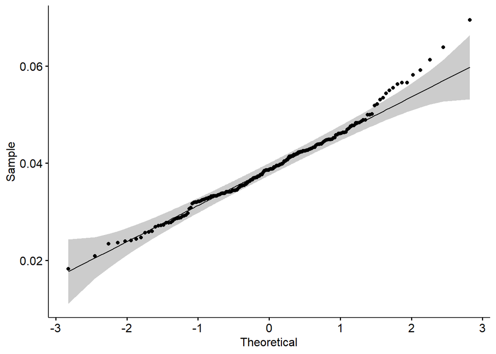

```r
ggqqplot(dados_feto$CEREBRO)
```

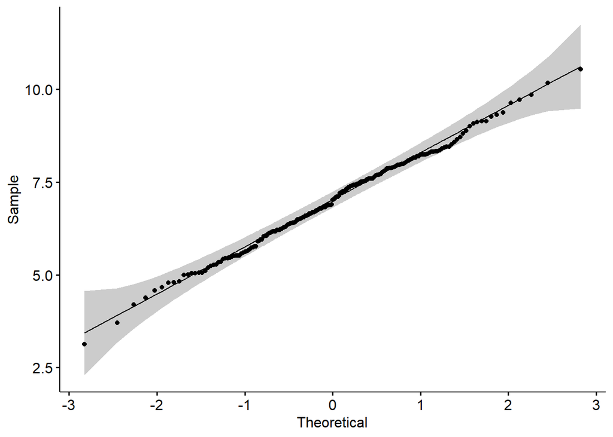

```r
ggqqplot(dados_feto$`(%) FÍGADO`)
```

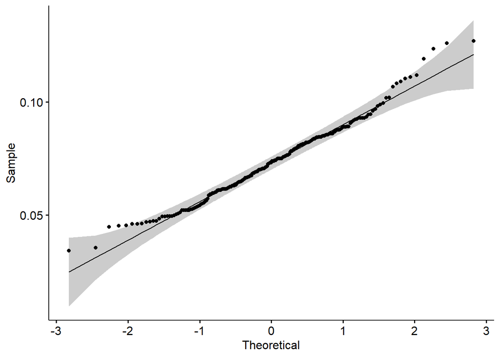

```r
ggqqplot(dados_feto$FÍGADO)
```

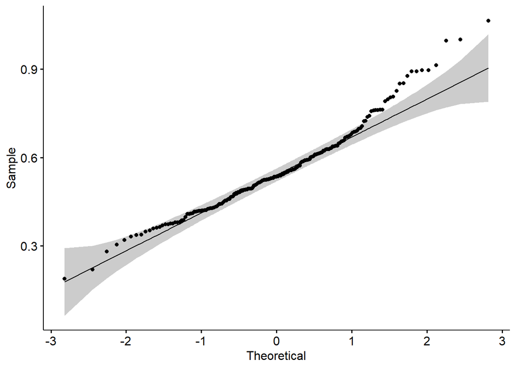

```r
ggqqplot(dados_feto$`PC/PF`)
```

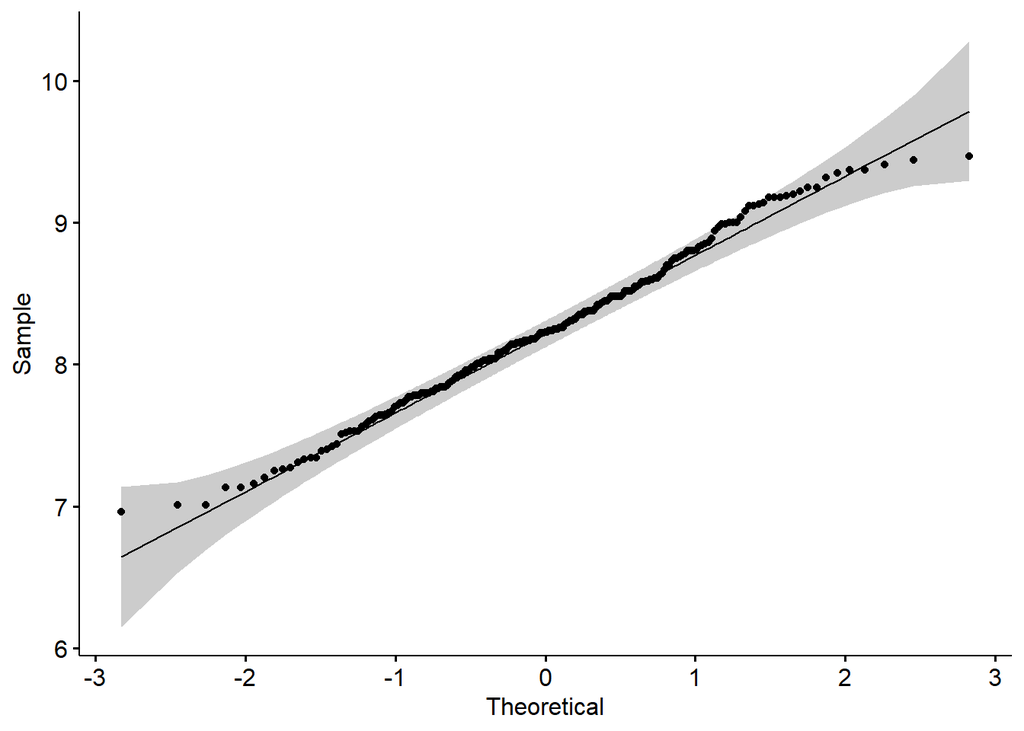

```r
ggqqplot(dados_feto$`DIAMETRO MEDIO PLACENTA`)
```

```r
# Teste de Shapiro-Wilk
shapiro.test(dados_feto$`Placenta-PESO`) #Apresenta Normalidade
```

```
##
##  Shapiro-Wilk normality test
##
## data:  dados_feto$`Placenta-PESO`
## W = 0.99003, p-value = 0.1624
```

```r
shapiro.test(dados_feto$PESO)#Não Apresenta Normalidade
```

```
##
##  Shapiro-Wilk normality test
##
## data:  dados_feto$PESO
## W = 0.97182, p-value = 0.0002895
```

```r
shapiro.test(dados_feto$`Eficiência Placentária`)# Apresenta Normalidade
```

```
##
##  Shapiro-Wilk normality test
##
## data:  dados_feto$`Eficiência Placentária`
## W = 0.98977, p-value = 0.1482
```

```r
shapiro.test(dados_feto$COMPRIMENTO)#Não Apresenta Normalidade
```

```
##
##  Shapiro-Wilk normality test
##
## data:  dados_feto$COMPRIMENTO
## W = 0.95638, p-value = 4.512e-06
```

```r
shapiro.test(dados_feto$`(%) CEREBRO`)#Não Apresenta Normalidade
```

```
##
##  Shapiro-Wilk normality test
##
## data:  dados_feto$`(%) CEREBRO`
## W = 0.92582, p-value = 8.368e-09
```

```r
shapiro.test(dados_feto$CEREBRO)#Não Apresenta Normalidade
```

```
##
##  Shapiro-Wilk normality test
##
## data:  dados_feto$CEREBRO
## W = 0.98272, p-value = 0.01125
```

```r
shapiro.test(dados_feto$`(%) FÍGADO`)# Apresenta Normalidade
```

```
##
##  Shapiro-Wilk normality test
##
## data:  dados_feto$`(%) FÍGADO`
## W = 0.99638, p-value = 0.9058
```

```r
shapiro.test(dados_feto$FÍGADO)#Não Apresenta Normalidade
```

```
##
##  Shapiro-Wilk normality test
##
## data:  dados_feto$FÍGADO
## W = 0.98141, p-value = 0.006918
```

```r
shapiro.test(dados_feto$`PC/PF`)#Não Apresenta Normalidade
```

```
##
##  Shapiro-Wilk normality test
##
## data:  dados_feto$`PC/PF`
## W = 0.96584, p-value = 6.334e-05
```

```r
shapiro.test(dados_feto$`DIAMETRO MEDIO PLACENTA`)# Apresenta Normalidade
```

```
##
##  Shapiro-Wilk normality test
##
## data:  dados_feto$`DIAMETRO MEDIO PLACENTA`
## W = 0.9908, p-value = 0.1953
```

## Testes de Hipótese

Nessa seção dividimos os testes paramétricos para aquelas variáveis que apresentaram normalidade, e os não-paramétricos para aqueles que não apresentaram normalidade.

### Paramétricos

#### Placenta-PESO

```r
mod <- aov(`Placenta-PESO` ~ `TRATAMENTO`, data = dados_feto)
anova(mod)
```

```
## Analysis of Variance Table
##
## Response: Placenta-PESO
##             Df   Sum Sq    Mean Sq F value  Pr(>F)
## TRATAMENTO   3 0.003802 0.00126741   2.405 0.06856 .
## Residuals  203 0.106978 0.00052698
## ---
## Signif. codes:  0 '***' 0.001 '**' 0.01 '*' 0.05 '.' 0.1 ' ' 1
```

Pelo p-valor da tabela ANOVA temos indícios de que os diferentes grupos de tratamento da variável ‘Placenta-PESO’, não apresentam diferenças estatisticamente significantes.

#### Eficiência Placentária

```r
mod <- aov(`Eficiência Placentária` ~ `TRATAMENTO`, data = dados_feto)
anova(mod)# os grupos apresentam diferença significativa
```

```
## Analysis of Variance Table
##
## Response: Eficiência Placentária
##             Df Sum Sq Mean Sq F value    Pr(>F)
## TRATAMENTO   3  39.25 13.0830   6.469 0.0003339 ***
## Residuals  203 410.55  2.0224
## ---
## Signif. codes:  0 '***' 0.001 '**' 0.01 '*' 0.05 '.' 0.1 ' ' 1
```

```r
bonferroni <- LSD.test(mod, "TRATAMENTO", p.adj="bonferroni", group=TRUE)
print(bonferroni)
```

```
## $statistics
##    MSerror  Df     Mean      CV
##   2.022407 203 7.080935 20.0837
##
## $parameters
##         test  p.ajusted     name.t ntr alpha
##   Fisher-LSD bonferroni TRATAMENTO   4  0.05
##
## $means
##          Eficiência Placentária      std  r      LCL      UCL      Min
## COCONUT                6.620582 1.305180 55 6.242490 6.998675 3.769681
## CONTROLE               6.899850 1.730363 62 6.543740 7.255959 3.793157
## LARD                   7.141898 1.209372 45 6.723901 7.559895 5.019251
## SOYBEAN                7.832123 1.275316 45 7.414126 8.250119 5.500830
##                Max      Q25      Q50      Q75
## COCONUT  10.002473 5.553446 6.664975 7.484170
## CONTROLE 10.910802 5.609488 6.835880 8.366097
## LARD      9.254176 6.117684 6.977312 7.817502
## SOYBEAN  10.800189 7.011473 7.729304 8.564751
##
## $comparison
## NULL
##
## $groups
##          Eficiência Placentária groups
## SOYBEAN                7.832123      a
## LARD                   7.141898     ab
## CONTROLE               6.899850      b
## COCONUT                6.620582      b
##
## attr(,"class")
## [1] "group"
```

Agora no teste para ‘Eficiência Placentária’ tivemos indícios de diferenças entre tratamentos na tabela ANOVA. Para analisar essas diferenças, fizemos o teste de comparações múltiplas de Bonferroni. Pelo teste, o grupo ‘Banha’ foi o único estatisticamente igual a todos outros, ‘Soja se diferenciou de ’Controle’ e ‘Coco’.

#### FÍGADO

```r
mod <- aov(`(%) FÍGADO` ~ `TRATAMENTO`, data = dados_feto)
anova(mod)
```

```
## Analysis of Variance Table
##
## Response: (%) FÍGADO
##             Df Sum Sq Mean Sq F value   Pr(>F)
## TRATAMENTO   3  19.13  6.3754  4.1675 0.006827 **
## Residuals  207 316.66  1.5298
## ---
## Signif. codes:  0 '***' 0.001 '**' 0.01 '*' 0.05 '.' 0.1 ' ' 1
```

```r
bonferroni <- LSD.test(mod, "TRATAMENTO", p.adj="bonferroni", group=TRUE)
print(bonferroni)
```

```
## $statistics
##    MSerror  Df    Mean       CV
##   1.529762 207 6.99167 17.69013
##
## $parameters
##         test  p.ajusted     name.t ntr alpha
##   Fisher-LSD bonferroni TRATAMENTO   4  0.05
##
## $means
##          (%) FÍGADO      std  r      LCL      UCL      Min       Max      Q25
## COCONUT    7.479990 1.187112 56 7.154144 7.805836 3.127471 10.172002 6.789298
## CONTROLE   6.779497 1.202079 66 6.479349 7.079644 4.574762  9.857341 6.040664
## LARD       6.939881 1.246336 43 6.568027 7.311735 3.706748  9.308357 6.292686
## SOYBEAN    6.750026 1.333229 46 6.390503 7.109550 4.203315 10.539953 5.703681
##               Q50      Q75
## COCONUT  7.600601 8.169141
## CONTROLE 6.671117 7.565265
## LARD     7.090214 7.760806
## SOYBEAN  6.390541 7.712603
##
## $comparison
## NULL
##
## $groups
##          (%) FÍGADO groups
## COCONUT    7.479990      a
## LARD       6.939881     ab
## CONTROLE   6.779497      b
## SOYBEAN    6.750026      b
##
## attr(,"class")
## [1] "group"
```

A variável ‘FÍGADO’ também indicou que deveriamos fazer o teste de bonferroni. Nele descobrimos resultados similares aos encontrados para ‘Eficiência Placentária’

#### DIAMETRO MEDIO PLACENTA

```r
mod <- aov(`DIAMETRO MEDIO PLACENTA` ~ `TRATAMENTO`, data = dados_feto)
anova(mod)
```

```
## Analysis of Variance Table
##
## Response: DIAMETRO MEDIO PLACENTA
##             Df Sum Sq Mean Sq F value    Pr(>F)
## TRATAMENTO   3  7.706 2.56876  9.4294 7.163e-06 ***
## Residuals  209 56.936 0.27242
## ---
## Signif. codes:  0 '***' 0.001 '**' 0.01 '*' 0.05 '.' 0.1 ' ' 1
```

```r
bonferroni <- LSD.test(mod, "TRATAMENTO", p.adj="bonferroni", group=TRUE)
print(bonferroni)
```

```
## $statistics
##     MSerror  Df     Mean       CV
##   0.2724191 209 8.242394 6.332357
##
## $parameters
##         test  p.ajusted     name.t ntr alpha
##   Fisher-LSD bonferroni TRATAMENTO   4  0.05
##
## $means
##          DIAMETRO MEDIO PLACENTA       std  r      LCL      UCL  Min  Max
## COCONUT                 8.018571 0.4875819 56 7.881074 8.156069 7.01 9.04
## CONTROLE                8.238939 0.4936586 66 8.112286 8.365593 7.20 9.44
## LARD                    8.569556 0.5092461 45 8.416171 8.722941 7.01 9.47
## SOYBEAN                 8.199783 0.6075287 46 8.048074 8.351491 6.96 9.35
##             Q25   Q50    Q75
## COCONUT  7.6650 8.035 8.3725
## CONTROLE 7.9375 8.210 8.4875
## LARD     8.1800 8.550 8.9900
## SOYBEAN  7.8025 8.180 8.6500
##
## $comparison
## NULL
##
## $groups
##          DIAMETRO MEDIO PLACENTA groups
## LARD                    8.569556      a
## CONTROLE                8.238939      b
## SOYBEAN                 8.199783      b
## COCONUT                 8.018571      b
##
## attr(,"class")
## [1] "group"
```

Por último no teste para a variável ‘DIAMETRO MEDIO PLACENTA’, encontramos evidências de que o grupo ‘Banha’ é significativamente diferente de todos outros grupos, que se assemelham entre si.